# R workshop

3<sup>rd</sup> June 2016

## R workshop

### Day 2 - advanced

## Modern R

[David Robinson](http://varianceexplained.org/) summarized the goal on his laptop

[figure not shown]

see also what Karl Broman is recommanding for [people who learnt R a while ago](http://kbroman.org/hipsteR/)

## Modern pipeline

[figure not shown]

source: [David Robinson](http://varianceexplained.org/r/broom-slides/) check out David's [broom presentation](http://varianceexplained.org/files/broom_presentation.pdf)

## reading data

Hadley Wickham and Wes McKinney recently released `feather`, a new python / R project.

It rapidly stores dataframes as binary files and preserves column types.

[figure not shown]

- [Rstudio blog](https://blog.rstudio.org/2016/03/29/feather/)
- [performance benchmark](https://blog.dominodatalab.com/the-r-data-i-o-shootout/)
- [github repo](https://github.com/wesm/feather)

## Managing multiple models

Tutorial based on the great conference by [Hadley Wickham](https://www.youtube.com/watch?v=rz3_FDVt9eg)

[figure not shown]

## purrr::map / dplyr::do

progress bar will be [added](https://github.com/hadley/purrr/issues/149)

[figure not shown]

## Functional programming and nested data_frames

Using `purrr` and `tidyr`. Hadley is focusing on every part of `R` to *clean* it up.

`purrr` revisits the `apply` family in a consistent way. `tidyr::nest` nests list in `tibble::data_frame` to keep related things together.

## For loops emphasise on objects and not actions

compare (notice `seq_along` instead of `1:length(mtcars)`)

```r
means <- vector("double", ncol(mtcars))
for (i in seq_along(mtcars)) {
  means[i] <- mean(mtcars[[i]])
}
means
```

```
##  [1]  20.090625   6.187500 230.721875 146.687500   3.596563   3.217250
##  [7]  17.848750   0.437500   0.406250   3.687500   2.812500
```

and

```r
library("purrr")
map_dbl(mtcars, mean)
```

```
##        mpg        cyl       disp         hp       drat         wt
##  20.090625   6.187500 230.721875 146.687500   3.596563   3.217250
##       qsec         vs         am       gear       carb
##  17.848750   0.437500   0.406250   3.687500   2.812500
```

## Nested map

```r
library("purrr")
library("dplyr", warn.conflicts = FALSE)
funs <- list(mean = mean, median = median, sd = sd)
funs %>%
  map(~ mtcars %>% map_dbl(.x))
```

```
## $mean
##        mpg        cyl       disp         hp       drat         wt
##  20.090625   6.187500 230.721875 146.687500   3.596563   3.217250
##       qsec         vs         am       gear       carb
##  17.848750   0.437500   0.406250   3.687500   2.812500
##
## $median
##     mpg     cyl    disp      hp    drat      wt    qsec      vs      am
##  19.200   6.000 196.300 123.000   3.695   3.325  17.710   0.000   0.000
##    gear    carb
##   4.000   2.000
##
## $sd
##         mpg         cyl        disp          hp        drat          wt
##   6.0269481   1.7859216 123.9386938  68.5628685   0.5346787   0.9784574
##        qsec          vs          am        gear        carb
##   1.7869432   0.5040161   0.4989909   0.7378041   1.6152000
```

## Keep related things together

Linear model *per* country

```r
library("gapminder")
library("tidyr")
by_country_lm <- gapminder %>%
  mutate(year1950 = year - 1950) %>%
  group_by(continent, country) %>%
  nest() %>%
  mutate(model = map(data, ~ lm(lifeExp ~ year1950, data = .x)))
by_country_lm
```

```
## Source: local data frame [142 x 4]
##
##    continent     country            data   model
##       (fctr)      (fctr)           (chr)   (chr)
## 1       Asia Afghanistan <tbl_df [12,5]> <S3:lm>
## 2     Europe     Albania <tbl_df [12,5]> <S3:lm>
## 3     Africa     Algeria <tbl_df [12,5]> <S3:lm>
## 4     Africa      Angola <tbl_df [12,5]> <S3:lm>
## 5   Americas   Argentina <tbl_df [12,5]> <S3:lm>
## 6    Oceania   Australia <tbl_df [12,5]> <S3:lm>
## 7     Europe     Austria <tbl_df [12,5]> <S3:lm>
## 8       Asia     Bahrain <tbl_df [12,5]> <S3:lm>
## 9       Asia  Bangladesh <tbl_df [12,5]> <S3:lm>
## 10    Europe     Belgium <tbl_df [12,5]> <S3:lm>
## ..       ...         ...             ...     ...
```

## broom cleanup

[figure not shown]

## Tidying model coefficients

Use broom to extract, as neat data frames out of `lm()`:

- coefficients estimates: **slope** and **intercept**
- \(r^2\)
- residuals

```r
library("broom")
models <- by_country_lm %>%
  mutate(glance  = map(model, glance),
         rsq     = glance %>% map_dbl("r.squared"),
         tidy    = map(model, tidy),
         augment = map(model, augment))
models
```

```
## Source: local data frame [142 x 8]
##
##    continent     country            data   model              glance
##       (fctr)      (fctr)           (chr)   (chr)               (chr)
## 1       Asia Afghanistan <tbl_df [12,5]> <S3:lm> <data.frame [1,11]>
## 2     Europe     Albania <tbl_df [12,5]> <S3:lm> <data.frame [1,11]>
## 3     Africa     Algeria <tbl_df [12,5]> <S3:lm> <data.frame [1,11]>
## 4     Africa      Angola <tbl_df [12,5]> <S3:lm> <data.frame [1,11]>
## 5   Americas   Argentina <tbl_df [12,5]> <S3:lm> <data.frame [1,11]>
## 6    Oceania   Australia <tbl_df [12,5]> <S3:lm> <data.frame [1,11]>
## 7     Europe     Austria <tbl_df [12,5]> <S3:lm> <data.frame [1,11]>
## 8       Asia     Bahrain <tbl_df [12,5]> <S3:lm> <data.frame [1,11]>
## 9       Asia  Bangladesh <tbl_df [12,5]> <S3:lm> <data.frame [1,11]>
## 10    Europe     Belgium <tbl_df [12,5]> <S3:lm> <data.frame [1,11]>
## ..       ...         ...             ...     ...                 ...
## Variables not shown: rsq (dbl), tidy (chr), augment (chr)
```

## Exploratory plots

## Does linear models fit all countries?

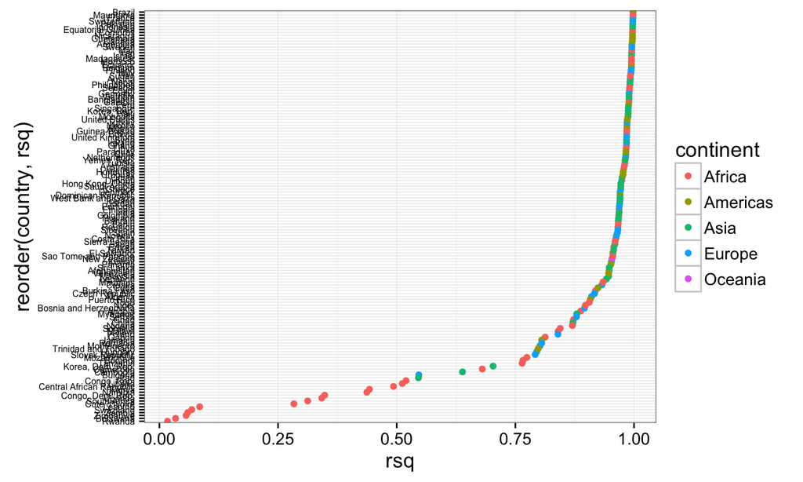

```r
library("ggplot2")
theme_set(theme_bw(14))
models %>%
  ggplot(aes(x = rsq, y = reorder(country, rsq)))+
  geom_point(aes(colour = continent))+
  theme(axis.text.y = element_text(size = 6))
```

## focus on non-linear trends

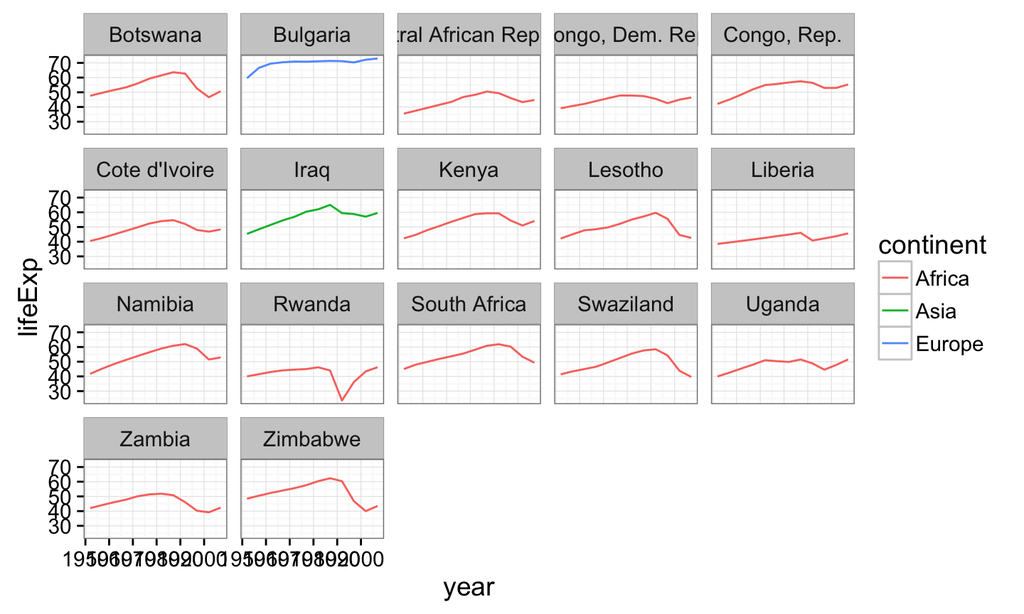

```r
models %>%
  filter(rsq < 0.55) %>%
  unnest(data) %>%
  ggplot(aes(x = year, y = lifeExp))+
  geom_line(aes(colour = continent))+
  facet_wrap(~ country)
```

## shiny - code

```r
library("shiny")
inputPanel(
  selectInput("country", "Select Country", levels(models$country))
)
output$rsq <- renderPlot({
  models %>%
  filter(country == input$country) %>%
  unnest(data) %>%
  ggplot(aes(x = year, y = lifeExp))+
  geom_line(aes(colour = continent))
})
renderUI({
 plotOutput("rsq", height = "400", width = "600")
})
```

## shiny

```r
library("shiny")
inputPanel(
  selectInput("country", "Select Country", levels(models$country))
)
output$country <- renderPlot({
  models %>%
  filter(country == input$country) %>%
  unnest(data) %>%
  ggplot(aes(x = year, y = lifeExp))+
  geom_line(aes(colour = continent))
})
renderUI({
 plotOutput("country", height = "400", width = "600")
})
```

## shiny - rsquare

```r
library("shiny")
inputPanel(
  sliderInput("rsq", "Select rsquared", min = 0, max = 1,
              value = c(0, 0.2), dragRange = TRUE)
)
output$rsq <- renderPlot({
  models %>%
  filter(rsq >= input$rsq[1], rsq <= input$rsq[2]) %>%
  unnest(data) %>%
  ggplot(aes(x = year, y = lifeExp))+
  geom_line(aes(colour = continent))+
  facet_wrap(~ country)
})
renderUI({
 plotOutput("rsq", height = "400", width = "600")
})
```

## All in all

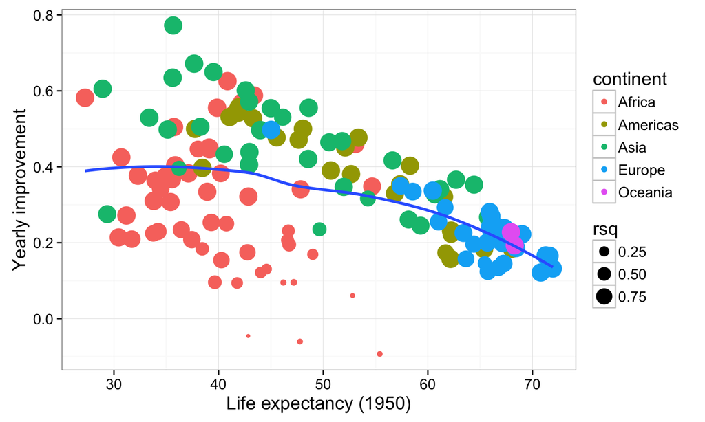

```r
models %>%
  unnest(tidy) %>%
  select(continent, country, rsq, term, estimate) %>%
  #filter(continent != "Africa") %>%
  spread(term, estimate) %>%
  ggplot(aes(x = `(Intercept)`, y = year1950))+
  geom_point(aes(colour = continent, size = rsq))+
  geom_smooth(se = FALSE)+
  scale_size_area()+
  labs(x = "Life expectancy (1950)",
       y = "Yearly improvement")
```

## Error handling

`purrr` proposes `safely()` and `possibly()` to enable error-handling.

safely() is a type-stable version of try. It always returns a list of two elements, the result and the error, and one will always be NULL.

```r
safely(log)(10)
```

```
## $result
## [1] 2.302585
##
## $error
## NULL
```

```r
safely(log)("a")
```

```
## $result
## NULL
##
## $error
## <simpleError in .f(...): non-numeric argument to mathematical function>
```

to be investigated

## Recommended reading

- [purrr applied](http://ijlyttle.github.io/isugg_purrr/presentation.html#%281%29) by Ian Lyttle
- [R for data science](http://r4ds.had.co.nz/intro.html) by Hadley
- [iterations - purrr](http://r4ds.had.co.nz/iteration.html) by Hadley
- [purrr 0.1](https://blog.rstudio.org/2015/09/29/purrr-0-1-0/) by Hadley
- [purrr 0.2](https://blog.rstudio.org/2016/01/06/purrr-0-2-0/) by Hadley

## Acknowledgments

- Hadley Wickham
- Robert Rudis
- Ian Lyttle
- David Robinson
- Eric Koncina